# Project: Investigate a Dataset ( No-show appointments)

- Introduction
- Data Wrangling
- Exploratory Data Analysis
- Conclusions

## Introduction

> The dataset that has been selected for analysis is the No_show appointmets dataset from Kaggle. The dataset has 14 columns and 110527 rows. The data has no null value however it is a mixture of Float, Int and Objects.

> This dataset collects information from 100k medical appointments in Brazil and is focused on the question of whether or not patients show up for their appointment

```python
import numpy as np
import pandas as pd
import matplotlib.pyplot as plt
import seaborn as sns

%matplotlib inline
```

## Data Wrangling

```python
#### Reading file
noShow = pd.read_csv(r'C:\Users\Poojan Mahajan\Desktop\Udacity_Sash\No_show_appointments.csv\KaggleV2_May_2016.csv')
noShow.head ()
```

|  | PatientId | AppointmentID | Gender | ScheduledDay | AppointmentDay | Age | Neighbourhood | Scholarship | Hipertension | Diabetes | Alcoholism | Handcap | SMS_received | No-show |
| --- | --- | --- | --- | --- | --- | --- | --- | --- | --- | --- | --- | --- | --- | --- |
| 0 | 2.987250e+13 | 5642903 | F | 2016-04-29T18:38:08Z | 2016-04-29T00:00:00Z | 62 | JARDIM DA PENHA | 0 | 1 | 0 | 0 | 0 | 0 | No |
| 1 | 5.589978e+14 | 5642503 | M | 2016-04-29T16:08:27Z | 2016-04-29T00:00:00Z | 56 | JARDIM DA PENHA | 0 | 0 | 0 | 0 | 0 | 0 | No |
| 2 | 4.262962e+12 | 5642549 | F | 2016-04-29T16:19:04Z | 2016-04-29T00:00:00Z | 62 | MATA DA PRAIA | 0 | 0 | 0 | 0 | 0 | 0 | No |
| 3 | 8.679512e+11 | 5642828 | F | 2016-04-29T17:29:31Z | 2016-04-29T00:00:00Z | 8 | PONTAL DE CAMBURI | 0 | 0 | 0 | 0 | 0 | 0 | No |
| 4 | 8.841186e+12 | 5642494 | F | 2016-04-29T16:07:23Z | 2016-04-29T00:00:00Z | 56 | JARDIM DA PENHA | 0 | 1 | 1 | 0 | 0 | 0 | No |

```python
noShow.describe()
```

|  | PatientId | AppointmentID | Age | Scholarship | Hipertension | Diabetes | Alcoholism | Handcap | SMS_received |
| --- | --- | --- | --- | --- | --- | --- | --- | --- | --- |
| count | 1.105270e+05 | 1.105270e+05 | 110527.000000 | 110527.000000 | 110527.000000 | 110527.000000 | 110527.000000 | 110527.000000 | 110527.000000 |
| mean | 1.474963e+14 | 5.675305e+06 | 37.088874 | 0.098266 | 0.197246 | 0.071865 | 0.030400 | 0.022248 | 0.321026 |
| std | 2.560949e+14 | 7.129575e+04 | 23.110205 | 0.297675 | 0.397921 | 0.258265 | 0.171686 | 0.161543 | 0.466873 |
| min | 3.921784e+04 | 5.030230e+06 | -1.000000 | 0.000000 | 0.000000 | 0.000000 | 0.000000 | 0.000000 | 0.000000 |
| 25% | 4.172614e+12 | 5.640286e+06 | 18.000000 | 0.000000 | 0.000000 | 0.000000 | 0.000000 | 0.000000 | 0.000000 |
| 50% | 3.173184e+13 | 5.680573e+06 | 37.000000 | 0.000000 | 0.000000 | 0.000000 | 0.000000 | 0.000000 | 0.000000 |
| 75% | 9.439172e+13 | 5.725524e+06 | 55.000000 | 0.000000 | 0.000000 | 0.000000 | 0.000000 | 0.000000 | 1.000000 |
| max | 9.999816e+14 | 5.790484e+06 | 115.000000 | 1.000000 | 1.000000 | 1.000000 | 1.000000 | 4.000000 | 1.000000 |

```python
noShow.info()
```

```
<class 'pandas.core.frame.DataFrame'>
RangeIndex: 110527 entries, 0 to 110526
Data columns (total 14 columns):
PatientId         110527 non-null float64
AppointmentID     110527 non-null int64
Gender            110527 non-null object
ScheduledDay      110527 non-null object
AppointmentDay    110527 non-null object
Age               110527 non-null int64
Neighbourhood     110527 non-null object
Scholarship       110527 non-null int64
Hipertension      110527 non-null int64
Diabetes          110527 non-null int64
Alcoholism        110527 non-null int64
Handcap           110527 non-null int64
SMS_received      110527 non-null int64
No-show           110527 non-null object
dtypes: float64(1), int64(8), object(5)
memory usage: 11.8+ MB
```

```python
noShow.shape
```

```
(110527, 14)
```

```python
noShow.dtypes
```

```
PatientId         float64
AppointmentID       int64
Gender             object
ScheduledDay       object
AppointmentDay     object
Age                 int64
Neighbourhood      object
Scholarship         int64
Hipertension        int64
Diabetes            int64
Alcoholism          int64
Handcap             int64
SMS_received        int64
No-show            object
dtype: object
```

```python
noShow.nunique()
```

```
PatientId          62299
AppointmentID     110527
Gender                 2
ScheduledDay      103549
AppointmentDay        27
Age                  104
Neighbourhood         81
Scholarship            2
Hipertension           2
Diabetes               2
Alcoholism             2
Handcap                5
SMS_received           2
No-show                2
dtype: int64
```

```python
noShow.tail()
```

|  | PatientId | AppointmentID | Gender | ScheduledDay | AppointmentDay | Age | Neighbourhood | Scholarship | Hipertension | Diabetes | Alcoholism | Handcap | SMS_received | No-show |
| --- | --- | --- | --- | --- | --- | --- | --- | --- | --- | --- | --- | --- | --- | --- |
| 110522 | 2.572134e+12 | 5651768 | F | 2016-05-03T09:15:35Z | 2016-06-07T00:00:00Z | 56 | MARIA ORTIZ | 0 | 0 | 0 | 0 | 0 | 1 | No |
| 110523 | 3.596266e+12 | 5650093 | F | 2016-05-03T07:27:33Z | 2016-06-07T00:00:00Z | 51 | MARIA ORTIZ | 0 | 0 | 0 | 0 | 0 | 1 | No |
| 110524 | 1.557663e+13 | 5630692 | F | 2016-04-27T16:03:52Z | 2016-06-07T00:00:00Z | 21 | MARIA ORTIZ | 0 | 0 | 0 | 0 | 0 | 1 | No |
| 110525 | 9.213493e+13 | 5630323 | F | 2016-04-27T15:09:23Z | 2016-06-07T00:00:00Z | 38 | MARIA ORTIZ | 0 | 0 | 0 | 0 | 0 | 1 | No |
| 110526 | 3.775115e+14 | 5629448 | F | 2016-04-27T13:30:56Z | 2016-06-07T00:00:00Z | 54 | MARIA ORTIZ | 0 | 0 | 0 | 0 | 0 | 1 | No |

```python
for i, v in enumerate(noShow.columns):
    print(i, v)
```

```
0 PatientId
1 AppointmentID
2 Gender
3 ScheduledDay
4 AppointmentDay
5 Age
6 Neighbourhood
7 Scholarship
8 Hipertension
9 Diabetes
10 Alcoholism
11 Handcap
12 SMS_received
13 No-show
```

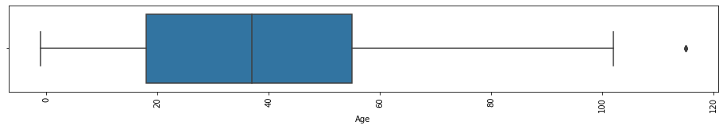

```python
# Checking with a boxplot for the distribution of age values
plt.figure(figsize=(16,2))
plt.xticks(rotation=90)
_ = sns.boxplot(x=noShow.Age)
```

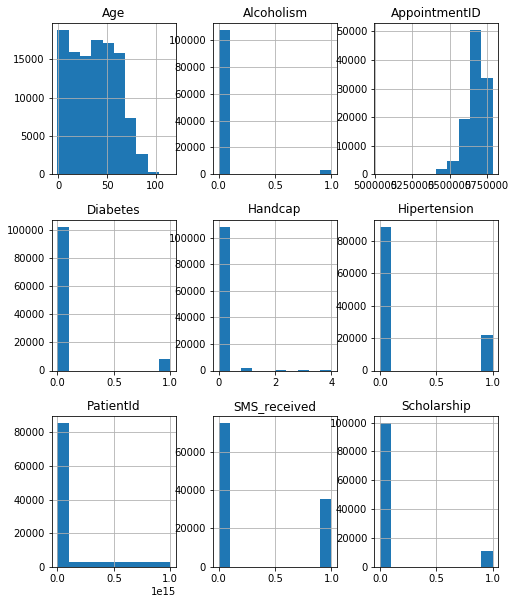

```python
noShow.hist(figsize=(8,10));
```

# Discussing the structure of the Data

There are 110527 records and 14 columns in the dataset.

### Prima Facie observations are:

1. There are 13 independent and one dependent variables in the data.
2. There is no NAN value.
3. Patient ID is a float.
4. Scheduled and Appointment day are objects where they can be date and time.
5. The column names need to be corrected of their spelling and format.
6. There is negative age.

### Data Cleaning

Columns are renamed appropriately. Date and Time is corrected along with the removal of absurd data from Age. Status (No-show) is changed to Integer. Age is formatted to a more believable number.

```python
# Renaming Columns
noShow.rename(columns = {'AppointmentID':'AppointmentId',
                         'Hipertension': 'Hypertension',
                         'HiperTension': 'Hypertension',
                         'Handcap': 'Handicap',
                         'SMS_received': 'SMS_Received'
                        }, inplace = True)
noShow.rename(columns={'No-show':'Status'}, inplace=True)
print(noShow.columns)
```

```
Index(['PatientId', 'AppointmentId', 'Gender', 'ScheduledDay',
       'AppointmentDay', 'Age', 'Neighbourhood', 'Scholarship', 'Hypertension',
       'Diabetes', 'Alcoholism', 'Handicap', 'SMS_Received', 'Status'],
      dtype='object')
```

```python
# Correcting Date and Time
noShow.AppointmentDay = noShow.AppointmentDay.apply(np.datetime64)
noShow.ScheduledDay = noShow.ScheduledDay.apply(np.datetime64)
print(noShow.AppointmentDay.head())
print(noShow.ScheduledDay.head())
```

```
0   2016-04-29
1   2016-04-29
2   2016-04-29
3   2016-04-29
4   2016-04-29
Name: AppointmentDay, dtype: datetime64[ns]
0   2016-04-29 18:38:08
1   2016-04-29 16:08:27
2   2016-04-29 16:19:04
3   2016-04-29 17:29:31
4   2016-04-29 16:07:23
Name: ScheduledDay, dtype: datetime64[ns]
```

```python
# removing absurd data from Age
noShow = noShow[(noShow.Age >= 0) & (noShow.Age <= 95)]
```

```python
#changing object in Status to integer
noShow['Status'] = noShow['Status'].map({'Yes': 1, 'No': 0})
```

```python
noShow.describe()
```

|  | PatientId | AppointmentId | Age | Scholarship | Hypertension | Diabetes | Alcoholism | Handicap | SMS_Received | Status |
| --- | --- | --- | --- | --- | --- | --- | --- | --- | --- | --- |
| count | 1.104800e+05 | 1.104800e+05 | 110480.000000 | 110480.000000 | 110480.000000 | 110480.000000 | 110480.000000 | 110480.000000 | 110480.000000 | 110480.000000 |
| mean | 1.474691e+14 | 5.675303e+06 | 37.063342 | 0.098307 | 0.197076 | 0.071841 | 0.030413 | 0.022167 | 0.321126 | 0.201955 |
| std | 2.560626e+14 | 7.128285e+04 | 23.079712 | 0.297731 | 0.397792 | 0.258226 | 0.171721 | 0.161252 | 0.466911 | 0.401461 |
| min | 3.921784e+04 | 5.030230e+06 | 0.000000 | 0.000000 | 0.000000 | 0.000000 | 0.000000 | 0.000000 | 0.000000 | 0.000000 |
| 25% | 4.172457e+12 | 5.640284e+06 | 18.000000 | 0.000000 | 0.000000 | 0.000000 | 0.000000 | 0.000000 | 0.000000 | 0.000000 |
| 50% | 3.172598e+13 | 5.680564e+06 | 37.000000 | 0.000000 | 0.000000 | 0.000000 | 0.000000 | 0.000000 | 0.000000 | 0.000000 |
| 75% | 9.438179e+13 | 5.725507e+06 | 55.000000 | 0.000000 | 0.000000 | 0.000000 | 0.000000 | 0.000000 | 1.000000 | 0.000000 |
| max | 9.999816e+14 | 5.790484e+06 | 95.000000 | 1.000000 | 1.000000 | 1.000000 | 1.000000 | 4.000000 | 1.000000 | 1.000000 |

## Exploratory Data Analysis

### 1. How many patients missed their scheduled appointment?

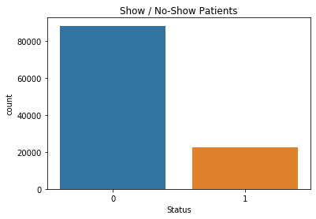

```
20% of appointments were missed.
```

```python
all_appointments = noShow.shape[0]
missed_appointments = len(noShow.query('Status == \'1\''))
missed_ratio = int(round(missed_appointments/all_appointments*100))

ax = sns.countplot(x=noShow.Status, data=noShow)
ax.set_title("Show / No-Show Patients")
plt.show();

print('{}% of appointments were missed.'.format(missed_ratio))
```

### 2. Are there patients with more than one appointment? What are the top 10?

```python
noShow.PatientId.value_counts().iloc[0:10]
```

```
8.221459e+14    88
9.963767e+10    84
2.688613e+13    70
3.353478e+13    65
6.264199e+12    62
7.579746e+13    62
2.584244e+11    62
8.713749e+14    62
6.684488e+13    57
8.722785e+11    55
Name: PatientId, dtype: int64
```

There are patients with more than one appointment. The maximum appointments taken are 88 by one individual patient.

### 3. What is the sex ratio comparison of missing appointments?

```python
# Finding all appointments attended by Male and Female seperately
all_appointments_by_f = len(noShow.loc[noShow['Gender'] == "F"])
all_appointments_by_m = len(noShow.loc[noShow['Gender'] == "M"])
```

```python
#Appointments missed and their Ratios
missed_appointments_by_f = len(noShow.query('Status == "1" and Gender == "F"'))
missed_appointments_by_m = len(noShow.query('Status == "1" and Gender == "M"'))

missed_ratio_f = int(round(missed_appointments_by_f/all_appointments_by_f*100))
missed_ratio_m = int(round(missed_appointments_by_m/all_appointments_by_m*100))
```

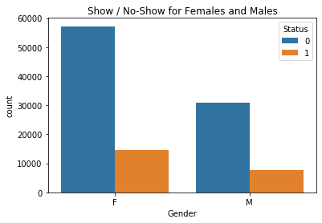

```
Out of 71802 appointments by females, 14588 were missed with the ratio of 20%.
Out of 38678 appointments made by males, 7724 were missed with the ratio of 20%.
```

```python
#Plotting
ax = sns.countplot(x=noShow.Gender, hue=noShow.Status, data=noShow)
ax.set_title("Show / No-Show for Females and Males")
x_ticks_labels=['Female', 'Male']
plt.show();

print('Out of {} appointments by females, {} were missed with the ratio of {}%.'.format(all_appointments_by_f, missed_appointments_by_f, missed_ratio_f))
print('Out of {} appointments made by males, {} were missed with the ratio of {}%.'.format(all_appointments_by_m, missed_appointments_by_m, missed_ratio_m))
```

### Additional statistical Observations

```python
np.corrcoef(noShow.Status,noShow.Alcoholism)
```

```
array([[ 1.00000000e+00, -2.06024672e-04],
       [-2.06024672e-04,  1.00000000e+00]])
```

```python
np.corrcoef(noShow.Status,noShow.Diabetes)
```

```
array([[ 1.        , -0.01509792],
       [-0.01509792,  1.        ]])
```

```python
np.corrcoef(noShow.Status,noShow.Hypertension)
```

```
array([[ 1.        , -0.03566053],
       [-0.03566053,  1.        ]])
```

```python
np.corrcoef(noShow.Status,noShow.Handicap)
```

```
array([[ 1.        , -0.00623433],
       [-0.00623433,  1.        ]])
```

```python
noShow.describe()
```

|  | PatientId | AppointmentId | Age | Scholarship | Hypertension | Diabetes | Alcoholism | Handicap | SMS_Received | Status |
| --- | --- | --- | --- | --- | --- | --- | --- | --- | --- | --- |
| count | 1.104800e+05 | 1.104800e+05 | 110480.000000 | 110480.000000 | 110480.000000 | 110480.000000 | 110480.000000 | 110480.000000 | 110480.000000 | 110480.000000 |
| mean | 1.474691e+14 | 5.675303e+06 | 37.063342 | 0.098307 | 0.197076 | 0.071841 | 0.030413 | 0.022167 | 0.321126 | 0.201955 |
| std | 2.560626e+14 | 7.128285e+04 | 23.079712 | 0.297731 | 0.397792 | 0.258226 | 0.171721 | 0.161252 | 0.466911 | 0.401461 |
| min | 3.921784e+04 | 5.030230e+06 | 0.000000 | 0.000000 | 0.000000 | 0.000000 | 0.000000 | 0.000000 | 0.000000 | 0.000000 |
| 25% | 4.172457e+12 | 5.640284e+06 | 18.000000 | 0.000000 | 0.000000 | 0.000000 | 0.000000 | 0.000000 | 0.000000 | 0.000000 |
| 50% | 3.172598e+13 | 5.680564e+06 | 37.000000 | 0.000000 | 0.000000 | 0.000000 | 0.000000 | 0.000000 | 0.000000 | 0.000000 |
| 75% | 9.438179e+13 | 5.725507e+06 | 55.000000 | 0.000000 | 0.000000 | 0.000000 | 0.000000 | 0.000000 | 1.000000 | 0.000000 |
| max | 9.999816e+14 | 5.790484e+06 | 95.000000 | 1.000000 | 1.000000 | 1.000000 | 1.000000 | 4.000000 | 1.000000 | 1.000000 |

## Conclusions

The data has been explored to find meaningful insights and correlation. The data has been reduced for the purpose of analysis, while considerable care has been taken to not remove the important aspects.

The findings suggest that more research is required into the topics discussed below. They will need statistical enquiry to validate results.

1. Most of the patients were not diagnosed as alcoholics, Diabetic, Hypertensed or Disabled.
2. More of the patients were Diabetic than Alcoholic.
3. The standard Deviation for Status (no-shows) is 0.4.
4. The average age of Patients is 37 where 25% are below the age of 18. Most of the patients lie between the age group of 20 and 60.
5. On average, 20% of appointments were missed.
6. There are patients with multiple appointments. Top 10 range between 88 to 55 appointments per person.
7. No distinction could be found between Males and Females for missing appointments.